# Ligand Activity Regressions: SIG19 (Treg depletion + cytokine blockade)

EYW

2026-09-07

```r
knitr::opts_chunk$set(echo = TRUE)
source("regression_helpers.R")
```

# Goal

Test which SIG13 ligand activities respond to in vivo antibody treatment in SIG19 inguinal lymph node CD4 T cells, using the activity scores from `02_score_disease_datasets.py`.

Treatment groups pair a Treg-perturbing antibody with a cytokine blockade:

| group | stimulation |
| --- | --- |
| `isotype` | control |
| `DTA1` | TNF. |
| `GK1.5-IL4` | IL4. |
| `GK1.5-BGo` | TGF-beta |
| `DTA1-IL4` | TNF + IL4 |
| `DTA1-BGo` | TNF + TGF-b |

This 2x2 layout supports a **synergy** test per combination: is the double treatment more than the sum of its single arms, `(DTA1-IL4 - GK1.5-IL4) - (DTA1 - isotype)`?

**Covariate: `sex`.** Cage is the other candidate – it is the shared-housing unit, and it is not aliased with treatment (each cage holds 3-4 treatment groups, each treatment spans 3-5 cages) – but with only 23 mice it costs 4 more residual df (12 vs 16) for very little change in the estimates themselves (r = 0.97 between the two models’ estimates, SEs 1.09x).

**Multiple testing: emmeans’ own adjustment**, i.e. across the contrast family within each activity – Dunnett for the vs-isotype comparisons, Tukey for the pairwise ones.

# Import

```r
SIG19_KEYS <- c("treatment", "mouse", "cage", "sex")
TREATMENTS <- c("isotype", "DTA1", "GK1.5-IL4", "GK1.5-BGo", "DTA1-IL4", "DTA1-BGo")

sig19 <- load_activity_scores("sig19_iln", SIG19_KEYS) %>%
  mutate(treatment = factor(treatment, TREATMENTS), cage = factor(cage), sex = factor(sex))

sig19_celltype <- load_activity_scores("sig19_iln_celltype", c(SIG19_KEYS, "leiden_0.5")) %>%
  rename(leiden = `leiden_0.5`) %>%
  mutate(treatment = factor(treatment, TREATMENTS),
         cage = factor(cage), sex = factor(sex),
         celltype = factor(paste0("cluster_", leiden)))

activities <- activity_names()
cat(nrow(sig19), "mice,", length(activities), "ligand activities\n")
```

```
## 23 mice, 38 ligand activities
```

```r
count(sig19, treatment, sex)
```

```
## # A tibble: 12 × 3
##    treatment sex       n
##    <fct>     <fct> <int>
##  1 isotype   F         3
##  2 isotype   M         3
##  3 DTA1      F         3
##  4 DTA1      M         2
##  5 GK1.5-IL4 F         2
##  6 GK1.5-IL4 M         1
##  7 GK1.5-BGo F         1
##  8 GK1.5-BGo M         2
##  9 DTA1-IL4  F         2
## 10 DTA1-IL4  M         1
## 11 DTA1-BGo  F         1
## 12 DTA1-BGo  M         2
```

```r
# synergy contrasts, in the order emmeans reports the treatment levels
levs <- levels(sig19$treatment)
synergy_contrasts <- list(
  "DTA1-IL4-synergy" = synergy_contrast(levs, both = "DTA1-IL4",
                                        single_a = "GK1.5-IL4", single_b = "DTA1",
                                        control = "isotype"),
  "DTA1-BGo-synergy" = synergy_contrast(levs, both = "DTA1-BGo",
                                        single_a = "GK1.5-BGo", single_b = "DTA1",
                                        control = "isotype")
)
```

# Treatment associations

## Each treatment vs isotype

```r
res_treatment <- fit_and_save(
  sig19,
  rhs = "treatment + sex",
  emm = ~ treatment,
  contrast_args = list(method = "trt.vs.ctrl", ref = "isotype"),
  name = "sig19_iln_treatment",
  padj_source = "emmeans"
)
```

```
## sig19_iln_treatment: 190 contrast x activity rows, 27 with padj < 0.1
```

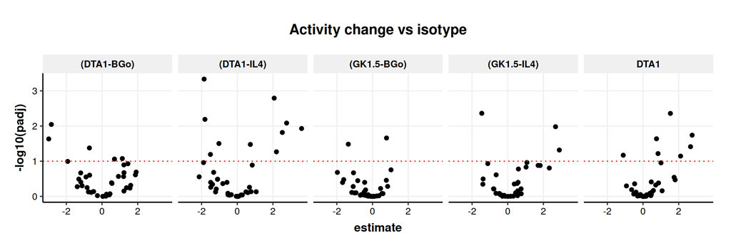

```r
res_treatment %>%
  mutate(contrast = str_remove(contrast, " - isotype")) %>%
  ggplot(aes(x = estimate, y = -log10(padj))) +
  geom_point() +
  geom_hline(yintercept = 1, linetype = "dotted", color = "red") +
  facet_wrap(~contrast, nrow = 1) +
  theme(aspect.ratio = 1) +
  labs(title = "Activity change vs isotype")
```

## All pairwise treatment comparisons

```r
res_pairs <- fit_and_save(
  sig19,
  rhs = "treatment + sex",
  emm = ~ treatment,
  contrast_args = list(method = "pairwise"),
  name = "sig19_iln_treatment_pairs",
  padj_source = "emmeans"
)
```

```
## sig19_iln_treatment_pairs: 570 contrast x activity rows, 81 with padj < 0.1
```

## Combination synergy

The synergy contrasts are user-specified weights, for which emmeans applies no adjustment at all – there is no Dunnett or Tukey family to correct within. These two models therefore keep the folder’s default, BH across the 38 activities within each contrast, so the synergy p-values stay corrected for something. (The original analysis corrected these with `p.adjust()`’s default, which is holm, not BH.)

```r
res_synergy <- fit_and_save(
  sig19,
  rhs = "treatment + sex",
  emm = ~ treatment,
  contrast_args = list(method = synergy_contrasts),
  name = "sig19_iln_treatment_synergy"
)
```

```
## sig19_iln_treatment_synergy: 76 contrast x activity rows, 5 with padj < 0.1
```

```r
res_synergy %>%
  filter(padj < 0.1) %>%
  select(contrast, component, estimate, padj) %>%
  arrange(padj)
```

```
## # A tibble: 5 × 4
##   contrast         component     estimate   padj
##   <chr>            <chr>            <dbl>  <dbl>
## 1 DTA1-IL4-synergy IL7_TNFSF18_c    -1.41 0.0497
## 2 DTA1-IL4-synergy TNFSF18_c        -2.33 0.0497
## 3 DTA1-BGo-synergy TGFB1            -1.35 0.0515
## 4 DTA1-IL4-synergy IL2_IFNB1_c      -4.35 0.0647
## 5 DTA1-IL4-synergy TNF_IFNB1_c      -4.24 0.0718
```

# Celltype associations

## Celltype identity

Which activities distinguish the leiden clusters from one another

```r
res_celltype <- fit_and_save(
  sig19_celltype,
  rhs = "celltype + sex",
  emm = ~ celltype,
  contrast_args = list(method = "del.eff"),
  name = "sig19_iln_celltype",
  padj_source = "emmeans"
)
```

```
## sig19_iln_celltype: 266 contrast x activity rows, 205 with padj < 0.1
```

```r
res_celltype_pairs <- fit_and_save(
  sig19_celltype,
  rhs = "celltype + sex",
  emm = ~ celltype,
  contrast_args = list(method = "pairwise"),
  name = "sig19_iln_celltype_pairs",
  padj_source = "emmeans"
)
```

```
## sig19_iln_celltype_pairs: 798 contrast x activity rows, 513 with padj < 0.1
```

## Treatment x celltype

```r
res_treatment_celltype <- fit_and_save(
  sig19_celltype,
  rhs = "treatment * celltype + sex",
  emm = ~ treatment | celltype,
  contrast_args = list(method = "trt.vs.ctrl", ref = "isotype"),
  padj_by = c("contrast", "celltype"),
  name = "sig19_iln_celltype_treatment",
  # padj_source = "emmeans"
)
```

```
## sig19_iln_celltype_treatment: 1330 contrast x activity rows, 189 with padj < 0.1
```

## Combination synergy x celltype

```r
res_synergy_celltype <- fit_and_save(
  sig19_celltype,
  rhs = "treatment * celltype + sex",
  emm = ~ treatment | celltype,
  contrast_args = list(method = synergy_contrasts),
  padj_by = c("contrast", "celltype"),
  name = "sig19_iln_celltype_treatment_synergy"
)
```

```
## sig19_iln_celltype_treatment_synergy: 532 contrast x activity rows, 28 with padj < 0.1
```

```r
res_synergy_celltype %>%
  filter(padj < 0.1) %>%
  count(contrast, celltype, name = "n_activities") %>%
  arrange(desc(n_activities))
```

```
## # A tibble: 5 × 3
##   contrast         celltype  n_activities
##   <chr>            <chr>            <int>
## 1 DTA1-IL4-synergy cluster_6           14
## 2 DTA1-BGo-synergy cluster_2           10
## 3 DTA1-IL4-synergy cluster_2            2
## 4 DTA1-IL4-synergy cluster_1            1
## 5 DTA1-IL4-synergy cluster_5            1
```

Results are written to `analysis_outs/inference_model_disease_bulk/regressions/` and visualized in `11_viz_sig19.Rmd`.